# Monte Carlo

### **Task: Monte-Carlo simulation**

Generate distribution of 0.01 quantile (1% percentile) of 10-days overlapping proportional returns obtained from the 3-years timeseries (750 observations) of 1-day returns.

Original timeseries is generated using stable distribution with the following parameters: alpha = 1.7; beta = 0.0; gamma = 1.0; delta = 1.0.

**Hint**

n-day returns: $$ r_{i}^{n} = \frac{P_{i+n} - P_{i}}{P_{i}} $$

### **Solution Plan**

We may represent the original problem in the form of the following subproblems[[1](https://www.wellesu.com/10.1007/978-3-030-52915-4)]:

1. Generate an initial time series

   A random variable $Z$ has the stable distribution if its characteristic function is given by $ S(\alpha, \beta, \gamma, \delta; k = 0)$:

   \begin{equation} \tag{1} \varphi_X(t) = \mathbb{E}[e^{itX}] = \begin{cases} \exp \left( -\gamma^{\alpha} |t|^{\alpha} \left[ 1 + i\beta \operatorname{sgn}(t) \tan \frac{\pi \alpha}{2} ((\gamma|t|)^{1-\alpha}-1) \right] + i\delta t \right), & \alpha \neq 1 \\ \exp \left( -\gamma |t| \left[ 1 + i\beta \operatorname{sgn}(t) \frac{2}{\pi} \ln (\gamma|t|) \right] + i\delta t \right), & \alpha = 1 \end{cases} \end{equation}

   where
   - $ \alpha $ is the stability parameter,
   - $ \beta $ is the skewness parameter,
   - $ \gamma $ is the scale parameter,
   - $ \delta $ is the location parameter,
   - $ \operatorname{sgn}(t) $ is the sign function [[1](https://www.wellesu.com/10.1007/978-3-030-52915-4)].

   A random value with specified parameters and corresponding distribution density will be required for the generation of a time series.

   The subject area of the current task is related to finance. To generate a time series of asset value, we can apply methods based on the Black-Scholes model, otherwise Stochastic Differential Model (SDE). Therefore, we resort to the most freely-quently used SDE, which is еquation as below:

   \begin{equation} \tag{2} P_{t+\Delta t} = P_t exp \left[ \left( \mu - \frac{\sigma^2}{2} \right )\Delta t +\sigma \sqrt{\Delta t} X \right] \end{equation}

   where
   - $ P_t $ is the price at time $t$,
   - $ \mu $ is the drift coefficient (average rate of return),
   - $ \sigma $ is the volatility coefficient (standard deviation),
   - $ X $ is the random number derived from a normal distribution with the expectation of 0 and the variance of 1 [[2](https://www.researchgate.net/publication/315119961_Does_the_VaR_Measurement_Using_Monte-Carlo_Simulation_Work_in_China-Evidence_from_Chinese_Listed_Banks)].

   The random number $ X $ can be obtained from Equation (1), with the requisite standardization. There are different techniques for selecting parameters $\mu$ and $\sigma$. In this work, we will assume that these parameters are constant for a period $T' = 3$ years. Let $ P_t $ us select an any stock, for example: the close price of Google stock.

   Let us define $T$ as the number of days relative to date $t$. Let us introduce a uniform grid with the number of nodes $N$, then

   \begin{equation} \tag{3} \Delta t = \frac{T}{N}. \end{equation}
2. Monte Carlo simulations should be conducted utilizing the findings from Step 1. It is necessary to repeat the experiment on generate of time series by changing random values.In this step, the number of repetitions or iterations $N_iter$ of the experiment is to be entered.
3. For each data set corresponding to one iteration, the proportional returns that overlap a 10-day period $r_{i}^{10}$ must be calculated:

   \begin{equation} \tag{4} r_{i}^{10} = \frac{P_{i+10} - P_{i}}{P_{i}}. \end{equation}

   The returns allows the calculation of a value $r_p$ which satisfies the condition $P(r < r_p) = 0.01$. This value $r_p$ is referred to as the 0.01 quantile.

   Once the values of the set $\{r_{p,i}: i$ is the number of iterations $\}$ have been determined, it is possible to obtain the distribution of the 0.01 quantile.

**List of references**

1. Nolan, John P. Univariate Stable Distributions: Models for Heavy Tailed Data. Springer International Publishing, 2020.
2. Wang, D., Song, J., & Lin, Y. (2017). Does the VaR Measurement using Monte-Carlo Si-mulation Work in China?—Evidence from Chinese Listed Banks. Journal of Financial Risk Management, 6, 66-78
3. С. С. Артемьев, А. А. Носикова, С. В. Солобоев, Метод Монте-Карло для моделирования цены акции, Сиб. журн. вычисл. матем., 2000, том 3, номер 1, 1–10

### **Step 1**: Create a stable distribution with the given parameters

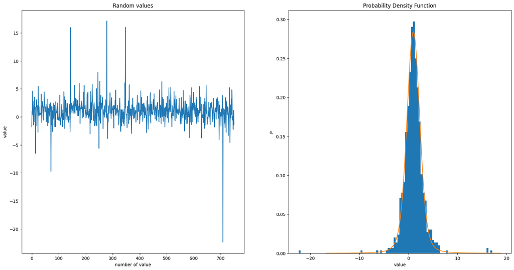

```python
import matplotlib.pyplot as plt # for graphics
import scipy.stats as st # for distribution
import numpy as np

# parametrs for stable distribution
alpha = 1.7
beta = 0
gamma = 1 #scale
delta = 1 #loc

# Probability Density Function
# default k=1, should change
st.levy_stable.parameterization = 'S0'
size = 750
rv = st.levy_stable(alpha = alpha, beta = beta, loc = delta, scale = gamma)
x = np.linspace(rv.ppf(0.001),
                rv.ppf(0.999), size)
r_values = rv.rvs(size)
fig, ax = plt.subplots(1,2, figsize = (20,10))
ax[0].plot(r_values)
ax[0].set_title('Random values');
ax[0].set_xlabel('number of value');
ax[0].set_ylabel('value');

ax[1].hist(r_values, density = True, lw = 2, bins = 100)
ax[1].plot(x,rv.pdf(x))
ax[1].set_title('Probability Density Function');
ax[1].set_xlabel('value');
ax[1].set_ylabel('P');
```

### **Step 2**: Calculate $\sigma_0$ and $\mu_0$

Let's represent the initial data as a sum of partition by time period $T_days = 10$. For each partition, we calculate the mean and standard deviation, and then average them.

```
[*********************100%%**********************]  1 of 1 completed
```

```
mu_0 = 0.0005503663461205114, sigma_0 = 0.01966270299388583
```

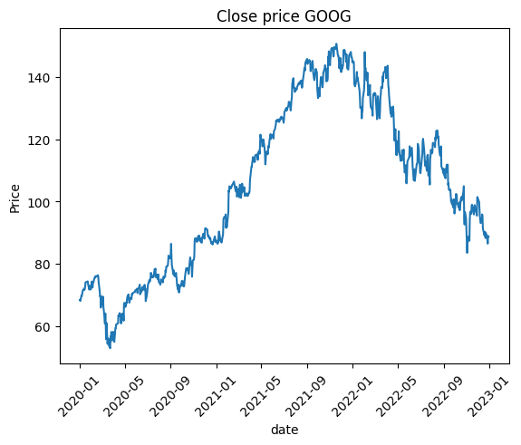

```python
import pandas as pd
import yfinance as yf
from typing import Union

# download close price
ticket = 'GOOG'
Data = yf.download(ticket, start = '2020-01-01', end = '2023-01-01')
plt.plot(Data['Close'])
plt.xticks(rotation = 45)
plt.title(f'Close price {ticket}')
plt.xlabel('date')
plt.ylabel('Price')


def get_current_params(Data: pd.DataFrame, T: int)-> Union[float,float]:
    """Calculate mu and sigma based on daily return
    Args:
        Data (pandas.DataFrame): Data['Close'] or other column
        T (int): partition period

    Returns:
        Union[float,float]: mu, sigma
    """
    dr = Data.pct_change()
    dr = dr.dropna()

    mean_dr = dr.rolling(T).mean()
    mean_dr = mean_dr.dropna()
    mu = mean_dr.mean()

    std_dr = dr.rolling(T).std()
    std_dr = std_dr.dropna()
    sigma = std_dr.mean()

    return mu, sigma

# calculation of starting mu and sigma parameters as mean, std
T_days = 10
mu_0, sigma_0 = get_current_params(Data['Close'], T_days)
print(f"mu_0 = {mu_0}, sigma_0 = {sigma_0}")
```

### **Step 3**: Generatioп test time series

In general, it is necessary to consider the impact of leap years, where the number of working(trading) days is 253 vs 252 days in non leap year. We may apply the Equation (3) to define $T=252*2+253$. Furthermore, it should be noted that $N = 750$.

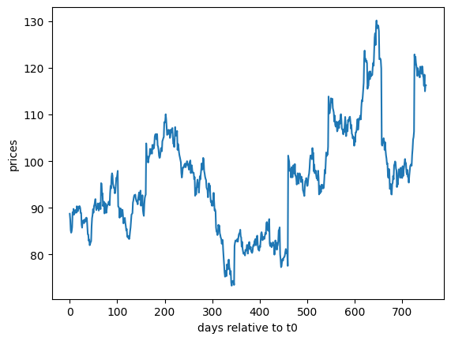

```python
def get_prices(N: int, T: int, P0: float, mu: float, sigma: float, random_values: np.ndarray) -> pd.DataFrame:
    """Get prices with const mu and sigma

    Args:
        N (int): is the number of nodes in the time period of interest
        T (int): is the time period
        P0 (float): is the start price
        mu (float): is the drift coefficient (average rate of return)
        sigma (float): is the volatility coefficient (standard deviation)
        random_value (np.ndarray): is the random values with given parameters

    Returns:
        pd.DataFrame: prices with P0
    """

    P = lambda t, P0, mu, sigma, random_value: P0*np.exp((mu - (sigma)**2/2)*t+sigma*np.sqrt(t)*random_value)
    delta_t = T/N
    prices = pd.DataFrame(P0)
    for t in range(N):
        prices.loc[len(prices)] = P(delta_t,prices.iloc[-1],mu_0,sigma_0,random_values[t])

    return prices


N = 750
T = (252*2+253)
P0 = [Data['Close'].iloc[-1]]
random_values = st.zscore(rv.rvs(N)) # standartization

prices = get_prices(N, T, P0, mu_0, sigma_0, random_values)
plt.plot(prices);
plt.xlabel('days relative to t0');
plt.ylabel('prices');
```

### Step 4: Monte-Carlo simulation

```python
N = 750
T = (252*2+253)
P0 = [Data['Close'].iloc[-1]]

N_iter = 1000
sim_Data = pd.DataFrame()

for i in range(N_iter):
    random_values = st.zscore(rv.rvs(N))
    sim_Data[i] =  get_prices(N, T, P0, mu_0, sigma_0, random_values)
```

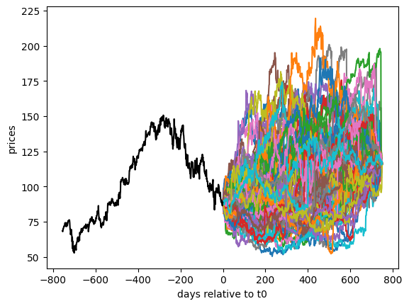

```python
for i in np.random.randint(0,N_iter,100):
    plt.plot(sim_Data[i])
plt.plot(np.arange(-len(Data['Close']),0),Data['Close'],'black')
plt.xlabel('days relative to t0')
plt.ylabel('prices')
```

### Step 5: Calculation of the 0.01 quantile for a single iteration.

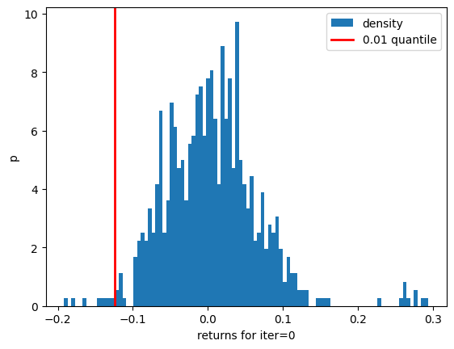

```python
def get_quantile(Data: pd.DataFrame, T_days: int, p: float)-> Union[np.ndarray, float]:
    """Calculation of the quantile for a single iteration

    Args:
        Data (DataFrame): prices
        T_days (int): is the number of n days return
        p (float): probability P(r<q)=p

    Returns:
        Union[np.ndarray, float]: returns, value of quantile
    """

    returns = Data.diff(T_days).dropna()
    returns = returns.values / Data[:-T_days].values
    q = np.quantile(returns,0.01)

    return returns, q


iter = 0
T_days = 10
p = 0.01

returns , q = get_quantile(sim_Data[iter], T_days, 0.01)

plt.hist(returns, density= True, bins=100, label='density');
plt.axvline(q, c = 'r', lw =2 , label= f'{p} quantile');
plt.ylabel('p')
plt.xlabel(f'returns for iter={iter}');
plt.legend();
```

### **Step 6**: Calculate of the distribution

We take a 1% quantile from each iteration of the stock price generation process and plot a histogram of the resulting distribution.

```
avg lose = -0.17879624992136234
```

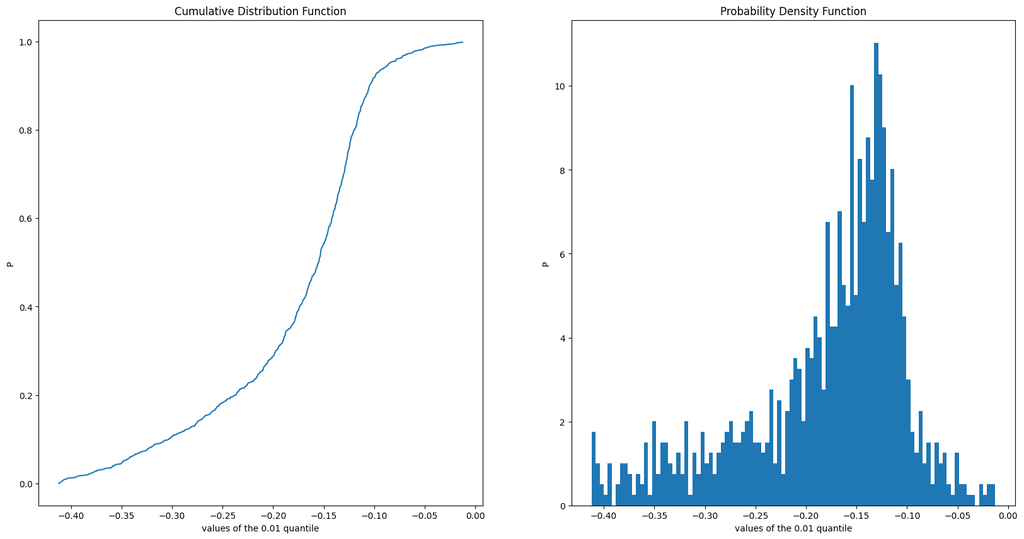

```python
quantiles = pd.DataFrame(columns=['value'])
T_days = 10
p = 0.01

for i in range(N_iter):
    _ , quantiles.loc[len(quantiles)] = get_quantile(sim_Data[i],T_days,p)

#Cumulative Distribution Function
sort_quantiles = quantiles.sort_values(by='value').reset_index()
sort_quantiles['F'] = sort_quantiles.index/len(quantiles)

fig, ax = plt.subplots(1,2, figsize = (20,10))
ax[0].plot(sort_quantiles['value'],sort_quantiles['F']);
ax[0].set_xlabel('values of the 0.01 quantile');
ax[0].set_ylabel('P');
ax[0].set_title('Cumulative Distribution Function');

ax[1].hist(quantiles, density = True, lw = 2, bins = 100)
ax[1].set_title('Probability Density Function');
ax[1].set_xlabel('values of the 0.01 quantile');
ax[1].set_ylabel('P');

print(f'avg lose = {np.mean(quantiles)}')
# normal distribution test
# res = st.anderson(quantiles['value'], dist = 'norm')
# res #not
```